# EDA Project

### Nutrients and At Risk Population

|  | total_calories | total_protein | total_carbs | total_sugars | total_fiber | glucose |
| --- | --- | --- | --- | --- | --- | --- |
| total_calories | 1.000000 | 0.765965 | 0.827485 | 0.593384 | 0.533770 | -0.051989 |
| total_protein | 0.765965 | 1.000000 | 0.488111 | 0.283274 | 0.462254 | -0.029771 |
| total_carbs | 0.827485 | 0.488111 | 1.000000 | 0.804371 | 0.553843 | -0.068054 |
| total_sugars | 0.593384 | 0.283274 | 0.804371 | 1.000000 | 0.302768 | -0.031096 |
| total_fiber | 0.533770 | 0.462254 | 0.553843 | 0.302768 | 1.000000 | -0.062901 |
| glucose | -0.051989 | -0.029771 | -0.068054 | -0.031096 | -0.062901 | 1.000000 |

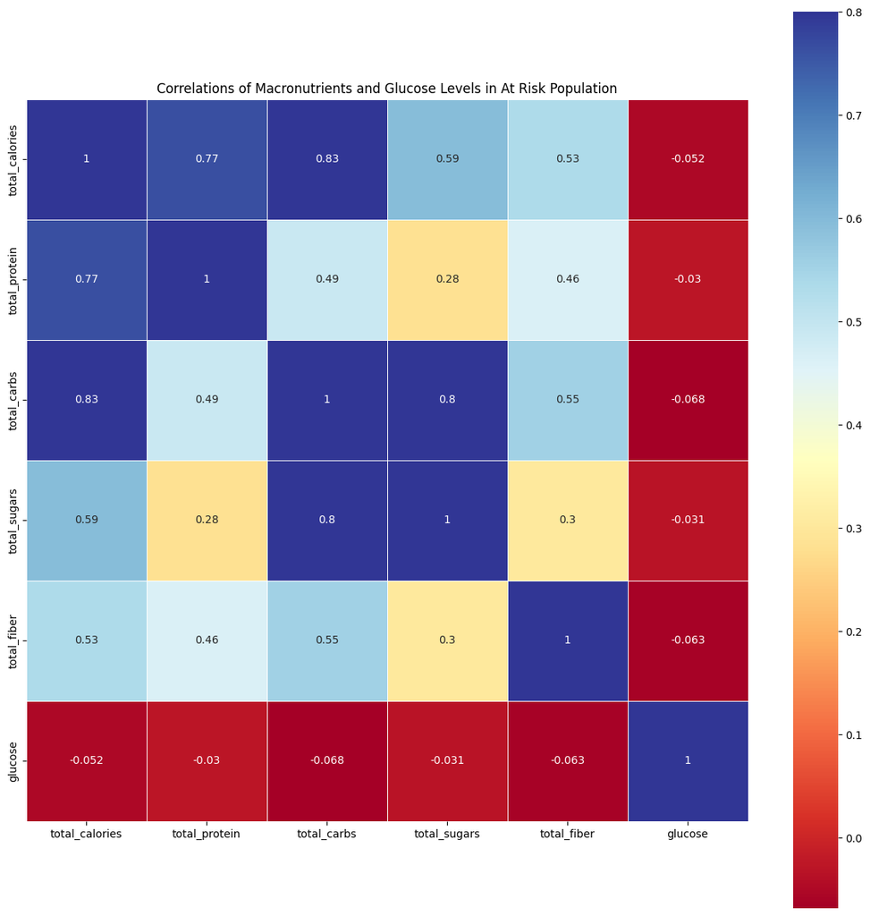

```python
# selecting for columns we want to examine
nutrients_atrisk_corr = nhanes_atrisk_nutrients[nutrientcorrcols]

# Creates a correlation matrix
corrmat = nutrients_atrisk_corr.corr(method = 'spearman')
corrmat

# Heatmap of correlation matrix
f, ax = plt.subplots(figsize = (15,15))
sns.heatmap(corrmat, vmax = .8, square = True, annot = True, cmap = 'RdYlBu', linewidths = .5 )
plt.title('Correlations of Macronutrients and Glucose Levels in At Risk Population')
plt.show()
```

Across all total macronutrients, the correlation with glucose levels for at risk population is a very weak negative correlation (all les than .07 in magnitude). This is more consistent (in terms of direction) and slightly stronger (in terms of magnitude) than trends seen in the general NHANES respondent population. However, the strength of these negative correlations being so low indicate that they are not reliable assessment tools for diabetes risk and glucose levels in the at risk population.

### Nutrients and Undiagnosed Population

|  | total_calories | total_protein | total_carbs | total_sugars | total_fiber | glucose |
| --- | --- | --- | --- | --- | --- | --- |
| total_calories | 1.000000 | 0.803989 | 0.832979 | 0.574613 | 0.618269 | 0.123875 |
| total_protein | 0.803989 | 1.000000 | 0.518435 | 0.251494 | 0.464351 | 0.051601 |
| total_carbs | 0.832979 | 0.518435 | 1.000000 | 0.802646 | 0.679939 | 0.029362 |
| total_sugars | 0.574613 | 0.251494 | 0.802646 | 1.000000 | 0.399169 | -0.088557 |
| total_fiber | 0.618269 | 0.464351 | 0.679939 | 0.399169 | 1.000000 | -0.046055 |
| glucose | 0.123875 | 0.051601 | 0.029362 | -0.088557 | -0.046055 | 1.000000 |

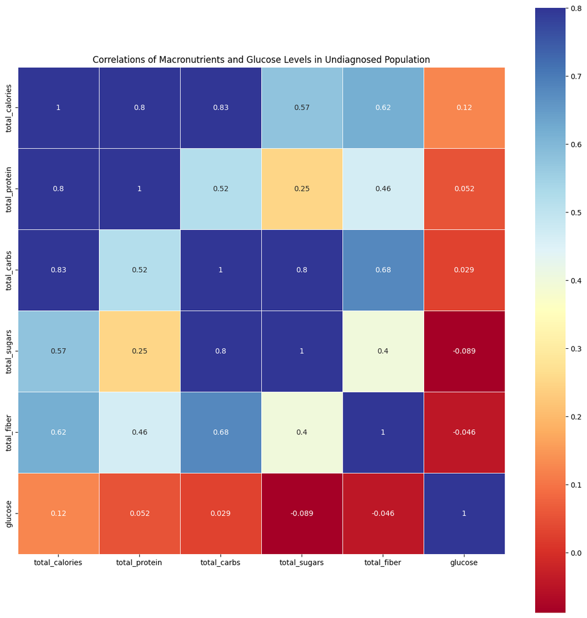

```python
# selecting for columns we want to examine
nutrients_undiagnosed_corr = nhanes_undiagnosed_nutrients[nutrientcorrcols]

# Creates a correlation matrix
corrmat = nutrients_undiagnosed_corr.corr(method = 'spearman')
corrmat

# Heatmap of correlation matrix
f, ax = plt.subplots(figsize = (15,15))
sns.heatmap(corrmat, vmax = .8, square = True, annot = True, cmap = 'RdYlBu', linewidths = .5 )
plt.title('Correlations of Macronutrients and Glucose Levels in Undiagnosed Population')
plt.show()
```

### Aim 3b: General Conclusions

Overall, macronutrient assessment is not a reliable diabetes risk assessment tool in general, at risk, and undiagnosed NHANES respondent populations. Associations between macronutrient consumption and glucose levels were generally very weak and inconsistent across populations. This is contrary to initial thoughts that macronutrient data would be a better assessment tool of patient diabetes risk.

# Overall Conclusions from EDA Part 2:

Generally, we see that waist circumference shows a stronger correlation to fasting glucose levels than BMI for general, at risk and undiagnosed respondent populations. This indicates that as a broad diabetes risk assessment tool, waist circumference could outperform BMI. However, there are some caveats. Among undiagnosed patients, waist circumference did not exhibit stronger correlation with fasting glucose than BMI for all racial/ethnic backgrounds reported. This indicates that waist circumference can vary slightly as a diabetes risk assessment tool in undiagnosed patient populations.

There was slight, but not substantial, differences in fasting glucose levels across gender and race in general, at risk and undiagnosed respondent populations.

Further, we saw that socioeconomic status is not strongly correlated with fasting glucose in any patient population. This indicates that it is likely not a good assessment tool for diabetes risk.

Similarly, macronutrient intakes were not strongly correlated with fasting glucose in any patient population. This also indicates that they are likely not good assessment tools for diabetes risk. One important factor with macronutrient intake that could be affecting it as a potential risk assessment tool is the data collection window and method used by NHANES. Respondents are asked to recall all they ate in the past 24 hours, which might not be reliable or a long enough analysis window to get a true sense of their everyday diet.

Overall, this EDA examined and determined best assessment tool approaches for diabetes risk.